# Importer, nettoyer et analyser des vraies données

Samuel BARRETO

# Objectif

L’idée de ce café est de reprendre tout ce qu’on a fait depuis le départ, et de l’appliquer à un nouveau jeu de donnée réel.

Ce jeu de donnée a été récolté par Cindy avec le compteur de colonies InterScience. En gros on a transformé une culture d’*Acinetobacter* à différentes DO600 par le même produit PCR, pour voir si on a un pic d’efficacité de transformation.

Donc après transformation on étale en duplicât un même volume sur un milieu sélectif, et en duplicât les dilutions $10^-4$ sur un milieu non sélectif, pour calculer une fréquence de transformation.

# Importation des données

## Création de la structure de dossier

Le jeu de donnée est disponible — comme la dernière fois — [à cette adresse](https://figshare.com/articles/cafe_recapitulatif/4580563).

Créez un nouveau dossier où vous voulez baptisé `cafe4`, contenant un dossier `analysis` et un dossier `data-raw`.

Télécharger les données, dézipper l’archive et placer les fichiers dans le dossier data-raw.

Maintenant grâce à RStudio ou à la commande `setwd()`, indiquer à `R` que le dossier `analysis` est le répertoire de travail (avec la petite molette de l’explorateur de fichier inclut dans RStudio).

Chouette. Vous pouvez vérifier que les fichiers du jeu de donnée sont bien dans le dossier `analysis` avec la commande `list.files("../data-raw/")`. S’il y a un message d’erreur, c’est certainement parce que vous n’êtes pas dans le bon dossier :).

Ok maintenant on peut les importer dans R.

## Importation via `read_delim`

Commençons par importer les deux fichiers les plus simples, `do.csv` et `id.csv`. Le premier contient la DO des différents réplicâts aux différents temps.

```r
do_file <- "../data-raw/do.csv"
```

```r
library(tidyverse)

df_DO600 <- read_csv(do_file)
df_DO600
```

```
## # A tibble: 54 × 3
##    temps réplicats do600
##    <chr>     <dbl> <dbl>
## 1     T0         1  0.13
## 2     T0         2  0.14
## 3     T0         3  0.14
## 4     T0         4  0.14
## 5     T0         5  0.14
## 6     T0         6  0.13
## 7     T1         1  0.24
## 8     T1         2  0.24
## 9     T1         3  0.24
## 10    T1         4  0.24
## # ... with 44 more rows
```

Chouette, celui là ne pose aucun problème, les données sont formattées correctement.

le deuxième — `id.csv` — contient les métadonnées qui ne sont pas présentes dans le fichier exporté par le logiciel InterScience.

```r
id_file <- "../data-raw/id.csv"
```

```r
df_id <- read_csv(id_file)
df_id
```

```
## # A tibble: 228 × 4
##       id     t   rep media
##    <int> <chr> <int> <chr>
## 1      1    T0     1   lbk
## 2      2    T0     1   lbk
## 3      3    T0     2   lbk
## 4      4    T0     2   lbk
## 5      5    T0     3   lbk
## 6      6    T0     3   lbk
## 7      7    T0     4   lbk
## 8      8    T0     4   lbk
## 9      9    T0     5   lbk
## 10    10    T0     5   lbk
## # ... with 218 more rows
```

Pareil, pas d’embrouilles. Celui là se charge facilement.

Par contre le dernier va nous poser problème. Si vous l’ouvrez dans un éditeur de texte, on voit ça :

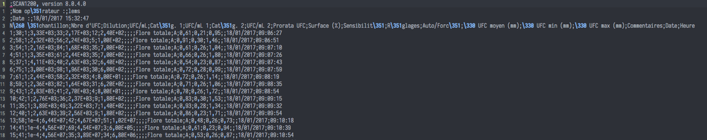

Ce qui nous indique plusieurs choses :

1. Que les premières lignes ne sont pas des noms de colonnes, on ne doit pas les prendre en compte.
2. Qu’il y a des caractères spéciaux bizarres dans les noms de colonnes, qu’on va devoir éliminer.
3. Qu’il y a beaucoup de colonnes qui ne servent certainement à rien.
4. Que les programmeurs de InterScience ne font pas beaucoup d’analyse de données.
5. Que le caractère pour délimiter les champs est un `;` et pas un `,`, contrairement à ce qui est attendu sous l’appelation `.csv`…

```r
df_file <- "../data-raw/170118.csv"
```

Ok, éliminons dans un premier temps le problème des premières lignes qui ne sont pas des noms de colonne.

```r
read_delim(df_file, skip = 3, delim = ";")
```

```
## Error in make.names(x): invalid multibyte string 1
```

Ok il doit y avoir un caractère bizarre dans les noms de colonne que R ne comprend pas trop trop. En tâtonnant un peu j’ai vu qu’il fallait changer l’encodage du fichier, un truc auquel je ne comprends pas grand chose, mais qui correspond à la façon dont les caractères sont représentés dans la mémoire de l’ordi.

```r
read_delim(df_file, skip = 3, delim = ";", locale = locale(encoding = "LATIN1"))
```

```
## # A tibble: 226 × 19
##    `N° échantillon` `Nbre d'UFC` Dilution `UFC/mL` `Catég. 1` `UFC/mL 1`
##               <int>        <int>    <dbl>    <chr>      <int>      <chr>
## 1                 1           30        1 3,33E+03         33   2,17E+03
## 2                 2           58        1 2,32E+03         56   2,24E+03
## 3                 3           54        1 2,16E+03         84   1,68E+03
## 4                 4           51        1 3,35E+03         61   2,44E+03
## 5                 5           37        1 4,11E+03         40   2,63E+03
## 6                 6           75        1 3,00E+03         98   1,96E+03
## 7                 7           61        1 2,44E+03         58   2,32E+03
## 8                 8           59        1 2,36E+03         82   1,64E+03
## 9                 9           43        1 2,83E+03         41   2,70E+03
## 10               10           42        1 2,76E+03         36   2,37E+03
## # ... with 216 more rows, and 13 more variables: `Catég. 2` <int>, `UFC/mL
## #   2` <chr>, `Prorata UFC` <chr>, `Surface (%)` <chr>, Sensibilité <chr>,
## #   Réglages <chr>, `Auto/Forcé` <chr>, `Ø UFC moyen (mm)` <chr>, `Ø UFC
## #   min (mm)` <chr>, `Ø UFC max (mm)` <chr>, Commentaires <chr>,
## #   Date <chr>, Heure <time>
```

Bon ok ça a l’air de marcher. Sauf que le cractère décimal est mal interprété.

```r
read_delim(df_file, skip = 3, delim = ";",
           locale = locale(encoding = "LATIN1", decimal_mark = ","))
```

```
## # A tibble: 226 × 19
##    `N° échantillon` `Nbre d'UFC` Dilution `UFC/mL` `Catég. 1` `UFC/mL 1`
##               <int>        <int>    <dbl>    <dbl>      <int>      <dbl>
## 1                 1           30        1     3330         33       2170
## 2                 2           58        1     2320         56       2240
## 3                 3           54        1     2160         84       1680
## 4                 4           51        1     3350         61       2440
## 5                 5           37        1     4110         40       2630
## 6                 6           75        1     3000         98       1960
## 7                 7           61        1     2440         58       2320
## 8                 8           59        1     2360         82       1640
## 9                 9           43        1     2830         41       2700
## 10               10           42        1     2760         36       2370
## # ... with 216 more rows, and 13 more variables: `Catég. 2` <int>, `UFC/mL
## #   2` <dbl>, `Prorata UFC` <chr>, `Surface (%)` <chr>, Sensibilité <chr>,
## #   Réglages <chr>, `Auto/Forcé` <chr>, `Ø UFC moyen (mm)` <dbl>, `Ø UFC
## #   min (mm)` <dbl>, `Ø UFC max (mm)` <dbl>, Commentaires <chr>,
## #   Date <chr>, Heure <time>
```

C’est mieux.

Sauvegardons donc ça.

```r
df <- read_delim(df_file, skip = 3, delim = ";",
                locale = locale(encoding = "LATIN1", decimal_mark = ","))
```

Les noms de colonnes sont tout bonnement — tout bonnement oui — impraticables dans R.

```r
colnames(df)
```

```
##  [1] "N° échantillon"   "Nbre d'UFC"       "Dilution"
##  [4] "UFC/mL"           "Catég. 1"         "UFC/mL 1"
##  [7] "Catég. 2"         "UFC/mL 2"         "Prorata UFC"
## [10] "Surface (%)"      "Sensibilité"      "Réglages"
## [13] "Auto/Forcé"       "Ø UFC moyen (mm)" "Ø UFC min (mm)"
## [16] "Ø UFC max (mm)"   "Commentaires"     "Date"
## [19] "Heure"
```

On va donc les nettoyer en un coup avec :

```r
df <- janitor::clean_names(df)

colnames(df)
```

```
##  [1] "n_échantillon"   "nbre_dufc"       "dilution"
##  [4] "ufc_ml"          "catég_1"         "ufc_ml_1"
##  [7] "catég_2"         "ufc_ml_2"        "prorata_ufc"
## [10] "surface_percent" "sensibilité"     "réglages"
## [13] "auto_forcé"      "ø_ufc_moyen_mm"  "ø_ufc_min_mm"
## [16] "ø_ufc_max_mm"    "commentaires"    "date"
## [19] "heure"
```

Nettement mieux. Maintenant on va sélectionner les colonnes qui nous intéressent, à savoir le numéro de l’échantillon, le nombre d’ufc et le nombre d’ufc par ml.

```r
df %>% select(n_échantillon, nbre_dufc, ufc_ml)
```

```
## # A tibble: 226 × 3
##    n_échantillon nbre_dufc ufc_ml
##            <int>     <int>  <dbl>
## 1              1        30   3330
## 2              2        58   2320
## 3              3        54   2160
## 4              4        51   3350
## 5              5        37   4110
## 6              6        75   3000
## 7              7        61   2440
## 8              8        59   2360
## 9              9        43   2830
## 10            10        42   2760
## # ... with 216 more rows
```

Nickel, on n’a pas besoin de plus. On sauvegarde :

```r
df <- df %>% select(n_échantillon, nbre_dufc, ufc_ml)
```

# Fusion des jeux de données

Il faut maintenant qu’on fusionne les infos présentes dans `df` avec celles présentes dans les deux autres.

```r
df
```

```
## # A tibble: 226 × 3
##    n_échantillon nbre_dufc ufc_ml
##            <int>     <int>  <dbl>
## 1              1        30   3330
## 2              2        58   2320
## 3              3        54   2160
## 4              4        51   3350
## 5              5        37   4110
## 6              6        75   3000
## 7              7        61   2440
## 8              8        59   2360
## 9              9        43   2830
## 10            10        42   2760
## # ... with 216 more rows
```

```r
df_id
```

```
## # A tibble: 228 × 4
##       id     t   rep media
##    <int> <chr> <int> <chr>
## 1      1    T0     1   lbk
## 2      2    T0     1   lbk
## 3      3    T0     2   lbk
## 4      4    T0     2   lbk
## 5      5    T0     3   lbk
## 6      6    T0     3   lbk
## 7      7    T0     4   lbk
## 8      8    T0     4   lbk
## 9      9    T0     5   lbk
## 10    10    T0     5   lbk
## # ... with 218 more rows
```

```r
df_DO600
```

```
## # A tibble: 54 × 3
##    temps réplicats do600
##    <chr>     <dbl> <dbl>
## 1     T0         1  0.13
## 2     T0         2  0.14
## 3     T0         3  0.14
## 4     T0         4  0.14
## 5     T0         5  0.14
## 6     T0         6  0.13
## 7     T1         1  0.24
## 8     T1         2  0.24
## 9     T1         3  0.24
## 10    T1         4  0.24
## # ... with 44 more rows
```

Il faut qu’on fusionne les deux derniers par la colonne réplicât et la colonne `t` ou `temps`.

```r
inner_join(x = df_id, y = df_DO600,
           by = c("t" = "temps", "rep" = "réplicats"))
```

```
## # A tibble: 216 × 5
##       id     t   rep media do600
##    <int> <chr> <dbl> <chr> <dbl>
## 1      1    T0     1   lbk  0.13
## 2      2    T0     1   lbk  0.13
## 3      3    T0     2   lbk  0.14
## 4      4    T0     2   lbk  0.14
## 5      5    T0     3   lbk  0.14
## 6      6    T0     3   lbk  0.14
## 7      7    T0     4   lbk  0.14
## 8      8    T0     4   lbk  0.14
## 9      9    T0     5   lbk  0.14
## 10    10    T0     5   lbk  0.14
## # ... with 206 more rows
```

Super, ça a l’air de marcher. Essayez de visualiser ce qu’il s’est passé ?

Sauvegardons le résultat.

```r
df_id_DO600 <- inner_join(x = df_id, y = df_DO600,
                         by = c("t" = "temps", "rep" = "réplicats"))
```

Maintenant fusionnons avec le jeu de donnée `df`.

```r
df
```

```
## # A tibble: 226 × 3
##    n_échantillon nbre_dufc ufc_ml
##            <int>     <int>  <dbl>
## 1              1        30   3330
## 2              2        58   2320
## 3              3        54   2160
## 4              4        51   3350
## 5              5        37   4110
## 6              6        75   3000
## 7              7        61   2440
## 8              8        59   2360
## 9              9        43   2830
## 10            10        42   2760
## # ... with 216 more rows
```

```r
df_id_DO600
```

```
## # A tibble: 216 × 5
##       id     t   rep media do600
##    <int> <chr> <dbl> <chr> <dbl>
## 1      1    T0     1   lbk  0.13
## 2      2    T0     1   lbk  0.13
## 3      3    T0     2   lbk  0.14
## 4      4    T0     2   lbk  0.14
## 5      5    T0     3   lbk  0.14
## 6      6    T0     3   lbk  0.14
## 7      7    T0     4   lbk  0.14
## 8      8    T0     4   lbk  0.14
## 9      9    T0     5   lbk  0.14
## 10    10    T0     5   lbk  0.14
## # ... with 206 more rows
```

L’ennui c’est qu’il y a des lignes dans la table `df` qui n’ont pas d’équivalent dans la table `df_id_DO600`.

```r
anti_join(x = df, y = df_id_DO600, by = c("n_échantillon" = "id"))
```

```
## # A tibble: 10 × 3
##    n_échantillon nbre_dufc   ufc_ml
##            <int>     <int>    <dbl>
## 1            226        43 4.30e+08
## 2            225        42 4.20e+08
## 3            224        85 1.68e+08
## 4            223        47 4.70e+08
## 5            222        68 2.64e+08
## 6            221        63 2.44e+08
## 7            220        44 4.40e+08
## 8            219        69 6.90e+08
## 9            218        72 2.79e+08
## 10           217        38 3.80e+08
```

La commande précédente veut dire : indiques-moi toutes les lignes de la table `df` qui n’ont pas d’équivalent dans la table `df_id_DO600`.

En fait ce sont les lignes qui correspondent aux témoins de transformations. On transforme par de l’eau au lieu d’un produit PCR et on voit si des clones transformants poussent sur LB + antibiotique. Là Cindy a dénombré les milieux non sélectifs, mais pas les sélectifs vu qu’il n’y avait rien dessus. Donc on peut laisser tomber ces lignes, pas d’intérêt de calculer une fréquence là dessus.

La commande suivante fait exactement ça, elle `join` les deux tables pour toutes les lignes qui ont des correspondances dans les deux tables, pour les colonnes indiquées dans l’argument `by` :

```r
(df_final <- inner_join(x = df, y = df_id_DO600, by = c("n_échantillon" = "id")))
```

```
## # A tibble: 216 × 7
##    n_échantillon nbre_dufc ufc_ml     t   rep media do600
##            <int>     <int>  <dbl> <chr> <dbl> <chr> <dbl>
## 1              1        30   3330    T0     1   lbk  0.13
## 2              2        58   2320    T0     1   lbk  0.13
## 3              3        54   2160    T0     2   lbk  0.14
## 4              4        51   3350    T0     2   lbk  0.14
## 5              5        37   4110    T0     3   lbk  0.14
## 6              6        75   3000    T0     3   lbk  0.14
## 7              7        61   2440    T0     4   lbk  0.14
## 8              8        59   2360    T0     4   lbk  0.14
## 9              9        43   2830    T0     5   lbk  0.14
## 10            10        42   2760    T0     5   lbk  0.14
## # ... with 206 more rows
```

Nickel !

On a enfin un jeu de donnée complet. On va pouvoir commencer les analyses !

Quoique.

# Ranger les données

Si on veut calculer une fréquence de transformation, il faut qu’on calcule la moyenne des transformants par mL sur la moyenne des cellules receveuses par mL, pour chaque temps et pour chaque réplicât.

```r
df_final %>%
  group_by(t, rep, media) %>%
  summarise(ufc_moyen = mean(ufc_ml))
```

```
## Source: local data frame [108 x 4]
## Groups: t, rep [?]
##
##        t   rep media ufc_moyen
##    <chr> <dbl> <chr>     <dbl>
## 1     T0     1    lb  55000000
## 2     T0     1   lbk      2825
## 3     T0     2    lb  39900000
## 4     T0     2   lbk      2755
## 5     T0     3    lb  41250000
## 6     T0     3   lbk      3555
## 7     T0     4    lb  43250000
## 8     T0     4   lbk      2400
## 9     T0     5    lb  42750000
## 10    T0     5   lbk      2795
## # ... with 98 more rows
```

Et là typiquement on a une table qui n’est pas rangée, ça va être difficile de calculer une fréquence de transformation avec un tableau comme ça. La colonne `media` contient deux types d’infos.

On va donc utiliser la fonction `spread` du package `tidyr`.

```r
df_final %>%
  group_by(t, rep, media) %>%
  summarise(ufc_moyen = mean(ufc_ml)) %>%
  spread(key = media, value = ufc_moyen)
```

```
## Source: local data frame [54 x 4]
## Groups: t, rep [54]
##
##        t   rep        lb   lbk
## *  <chr> <dbl>     <dbl> <dbl>
## 1     T0     1  55000000  2825
## 2     T0     2  39900000  2755
## 3     T0     3  41250000  3555
## 4     T0     4  43250000  2400
## 5     T0     5  42750000  2795
## 6     T0     6  47250000  3260
## 7     T1     1  81800000  3610
## 8     T1     2  63350000  3260
## 9     T1     3 106500000  2770
## 10    T1     4  66200000  3450
## # ... with 44 more rows
```

Nickel.

Maintenant c’est facile de calculer un ratio avec la commande `mutate`.

```r
df_final %>%
  group_by(t, rep, media) %>%
  summarise(ufc_moyen = mean(ufc_ml)) %>%
  spread(key = media, value = ufc_moyen) %>%
  mutate(ratio = lbk / lb)
```

```
## Source: local data frame [54 x 5]
## Groups: t, rep [54]
##
##        t   rep        lb   lbk        ratio
##    <chr> <dbl>     <dbl> <dbl>        <dbl>
## 1     T0     1  55000000  2825 5.136364e-05
## 2     T0     2  39900000  2755 6.904762e-05
## 3     T0     3  41250000  3555 8.618182e-05
## 4     T0     4  43250000  2400 5.549133e-05
## 5     T0     5  42750000  2795 6.538012e-05
## 6     T0     6  47250000  3260 6.899471e-05
## 7     T1     1  81800000  3610 4.413203e-05
## 8     T1     2  63350000  3260 5.146014e-05
## 9     T1     3 106500000  2770 2.600939e-05
## 10    T1     4  66200000  3450 5.211480e-05
## # ... with 44 more rows
```

Super, on a notre ratio.

L’ennui c’est qu’on veut représenter ce ratio comme une fonction de la DO de la culture de base. Il faut donc qu’on fusionne cette table avec la table contenant les informations de DO, `df_DO600`.

```r
df_final %>%
  group_by(t, rep, media) %>%
  summarise(ufc_moyen = mean(ufc_ml)) %>%
  spread(key = media, value = ufc_moyen) %>%
  mutate(ratio = lbk / lb) %>%
  inner_join(x = ., y = df_DO600, by = c("t" = "temps", "rep" = "réplicats"))
```

```
## Source: local data frame [54 x 6]
## Groups: t, rep [?]
##
##        t   rep        lb   lbk        ratio do600
##    <chr> <dbl>     <dbl> <dbl>        <dbl> <dbl>
## 1     T0     1  55000000  2825 5.136364e-05  0.13
## 2     T0     2  39900000  2755 6.904762e-05  0.14
## 3     T0     3  41250000  3555 8.618182e-05  0.14
## 4     T0     4  43250000  2400 5.549133e-05  0.14
## 5     T0     5  42750000  2795 6.538012e-05  0.14
## 6     T0     6  47250000  3260 6.899471e-05  0.13
## 7     T1     1  81800000  3610 4.413203e-05  0.24
## 8     T1     2  63350000  3260 5.146014e-05  0.24
## 9     T1     3 106500000  2770 2.600939e-05  0.24
## 10    T1     4  66200000  3450 5.211480e-05  0.24
## # ... with 44 more rows
```

Ça marche.

Maintenant on peut faire des graphiques.

# Analyses graphiques

Ici je ne présente que la dernière version du graphique, mais naturellement on fait ça de façon itérative, couche après couche.

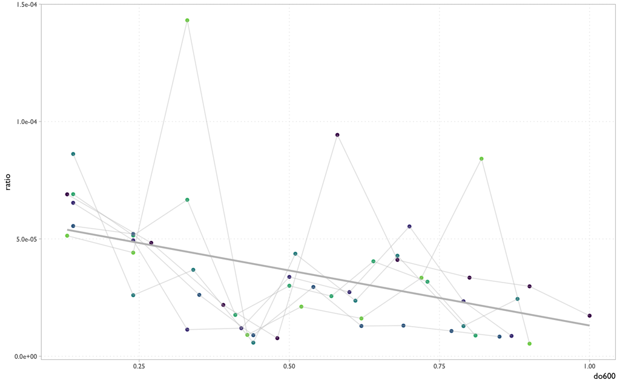

```r
## le package scales permet d'utiliser différentes échelles, notamment des
## labels scientifiques. 1.5e-04 c'est mieux que 0.00015 non ?
library(scales)
## pour des jolies palettes de couleur
library(viridis)

df_final %>%
  group_by(t, rep, media) %>%
  summarise(ufc_moyen = mean(ufc_ml)) %>%
  spread(key = media, value = ufc_moyen) %>%
  mutate(ratio = lbk / lb) %>%
  inner_join(x = ., y = df_DO600, by = c("t" = "temps", "rep" = "réplicats")) %>%
  ggplot(aes(x = do600, y = ratio)) +
  geom_point(aes(color = factor(rep))) +
  geom_line(aes(group = rep), color = "gray", alpha = 0.4) +
  geom_smooth(method = "lm", se = FALSE, color = "gray") +
  guides(color = "none") +
  ## c'est ici que le package scales intervient
  scale_y_continuous(label = scientific) +
  ## et là que le package viridis intervient
  scale_color_viridis(discrete = TRUE, direction = -1, end = 0.8)
```

Un effet ou bien ?

```r
df_final %>%
  group_by(t, rep, media) %>%
  summarise(ufc_moyen = mean(ufc_ml)) %>%
  spread(key = media, value = ufc_moyen) %>%
  mutate(ratio = lbk / lb) %>%
  inner_join(x = ., y = df_DO600, by = c("t" = "temps", "rep" = "réplicats")) %>%
  lm(data = ., ratio ~ do600) %>%
  summary()
```

```
##
## Call:
## lm(formula = ratio ~ do600, data = .)
##
## Residuals:
##        Min         1Q     Median         3Q        Max
## -3.356e-05 -1.414e-05 -3.637e-06  9.757e-06  9.863e-05
##
## Coefficients:
##               Estimate Std. Error t value Pr(>|t|)
## (Intercept)  5.999e-05  7.900e-06   7.593 5.62e-10
## do600       -4.688e-05  1.374e-05  -3.413  0.00125
##
## Residual standard error: 2.443e-05 on 52 degrees of freedom
## Multiple R-squared:  0.183,  Adjusted R-squared:  0.1673
## F-statistic: 11.65 on 1 and 52 DF,  p-value: 0.001254
```

Bon bah à priori, il y a un effet significatif de la DO sur l’efficacité de transformation. Donc on peut arrêter de faire pousser nos cellules. On va faire les transfos directement dans le glycérol maintenant.

Chouette, on va gagner pas mal de temps.